# Model selection: Economic growth Notebook

Bikramjit Das

2025

# 1 The Economic Growth data set

- We will use a data set that was used in the papers: **I just ran two million regressions** by *Sala-I-Martin* and **Model uncertainty in cross country growth regression** by *Fernandez et. al.*
- The data set has 41 possible explanatory variables with 72 countries. The data consists of 43 columns with the Country, `y` (economic growth in per capita GDP) and 41 possible predictor variables.

```r
rm(list=ls()) # remove all objects

eg <- read.csv("economicgrowth.csv")
str(eg)
eg1 <- subset(eg,select=-c(Country))
str(eg1)
```

- We now conduct model selection by exhaustive search. Note that we have 2^41 which is approximately 2 trillion possible regressions to run.
- The `leaps` package has some smart ways to search over this space by avoiding visiting parts of the space where the optimum cannot exist. It employs a *branch and bound* algorithm to search more efficiently. This would take a few minutes to run on a laptop.
- The model shows the bias-variance trade-off. We can also plot the variables identified using the plot command.

## 1.1 Best subset selection

```r
library(leaps)
model1 <- regsubsets(y~.,data=eg1,nvmax=41)
```

A summary of `model1` is given below:

```r
summary(model1)
```

### 1.1.1 Plots of $R^2$, Adjusted-$R^2$.

We plot $R^2$ and Adjusted-$R^2$ for the best subset of a particular size.

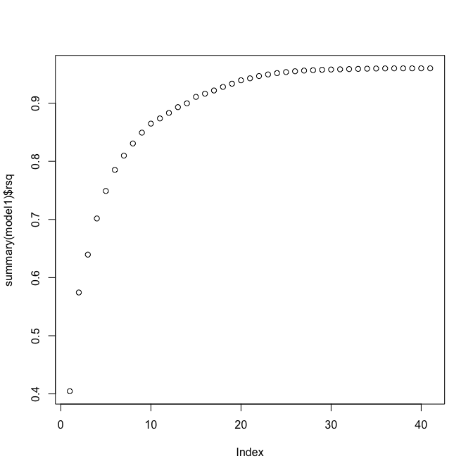

```r
plot(summary(model1)$rsq)
```

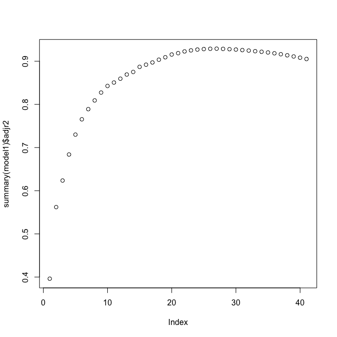

```r
plot(summary(model1)$adjr2)
```

```r
which.max(summary(model1)$adjr2)  ### which model is the best model
```

```
## [1] 27
```

Naturally $R^2$ increases as the number of explanatory variables increase. On the other hand Adjusted-$R^2$ increases first and then decreases. We find that it reaches a maximum for a subset of size 27.

### 1.1.2 Plots of the best subset selected

Here we plot the best subset of different sizes which are selected using $R^2$ and Adjusted-$R^2$.

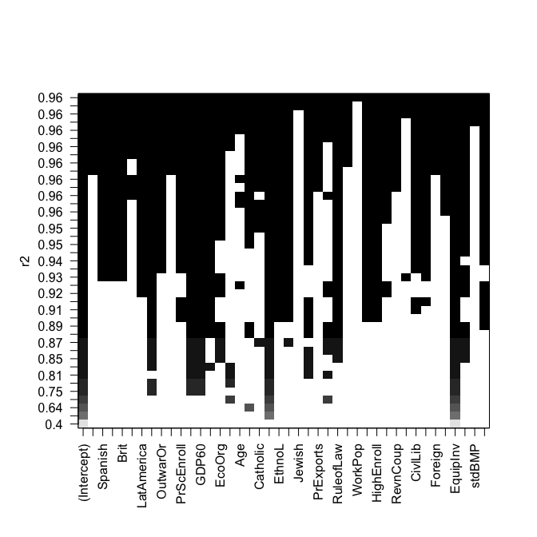

```r
plot(model1,scale=c("r2"))
```

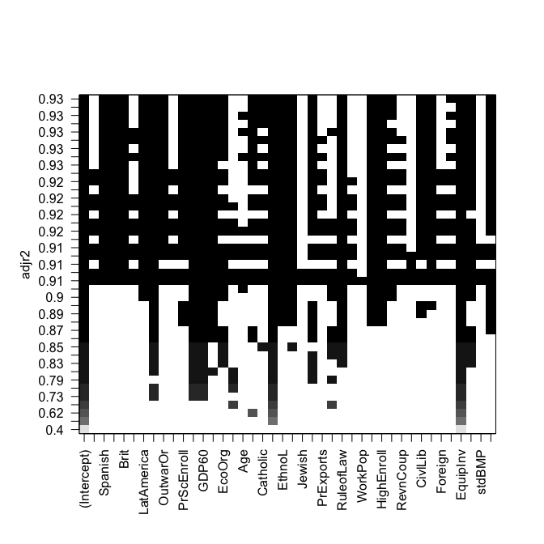

```r
plot(model1,scale=c("adjr2"))
```

## 1.2 Forward subset selection

We next use the forward step-wise selection method which runs much faster as should be expected. Note that the results are not identical to what we obtained with the exhaustive selection approach.

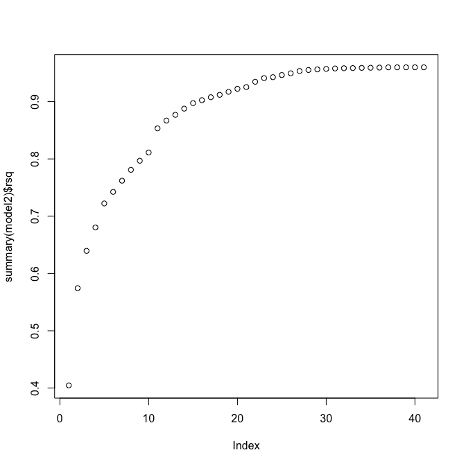

```r
model2 <- regsubsets(y~.,data=eg1,nvmax=41,method="forward")

plot(summary(model2)$rsq)
```

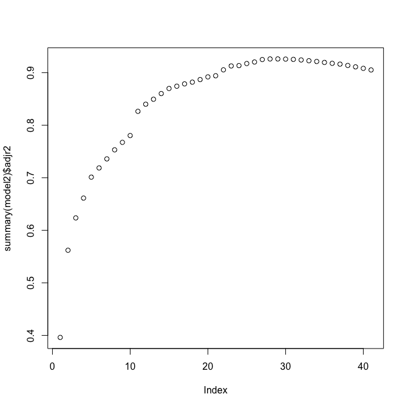

```r
plot(summary(model2)$adjr2)
```

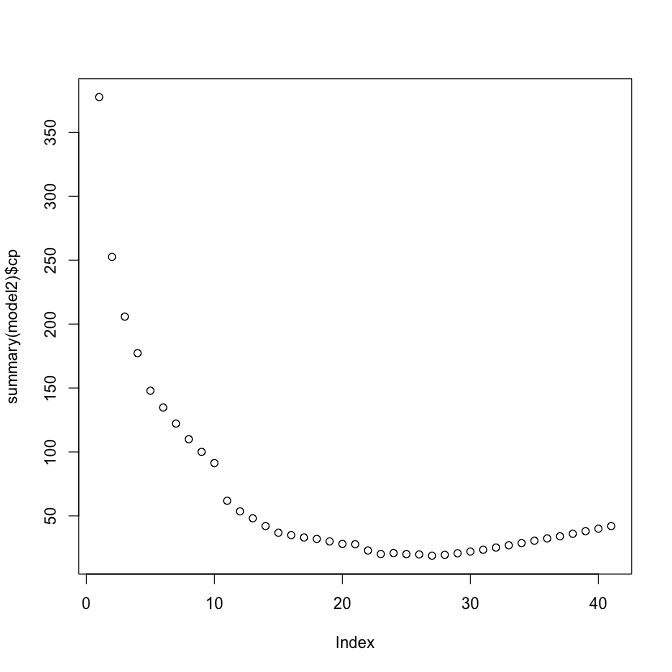

```r
plot(summary(model2)$cp)   ## Mallow's Cp
```

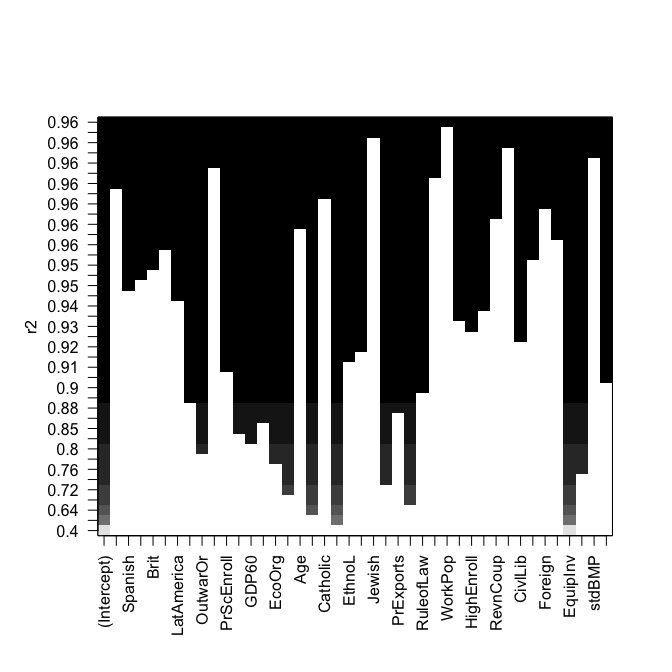

```r
plot(model2,scale=c("r2"))
```

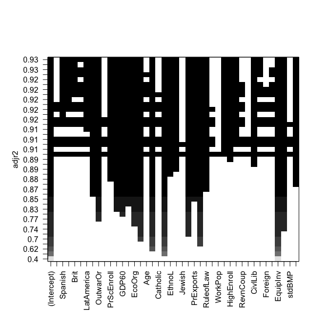

```r
plot(model2,scale=c("adjr2"))
```

## 1.3 Which variables are selected using Best subset and Forward subset?

```r
summary(model1)$which
summary(model2)$which
```

[output not shown]

The results indicate that with `model 1`, we have  
1) `EquipInv`,  
2) `Confucian`, `EquipInv`,  
3) `Buddha`, `Confucian`, `EquipInv`,  
4) `YrsOpen`, `Confucian`, `Protestants`, `EquipInv`

while for `model 2`, we have

1. `EquipInv`,
2. `Confucian`, `EquipInv`,
3. `Buddha`, `Confucian`, `EquipInv`,
4. `Buddha`, `Protestants`, `EquipInv`, `Confucian`  
   and so on.
- The results are different from the two models.

# 2 LASSO

We use the library `glmnet` to perform LASSO.

```r
library(glmnet)
x <- as.matrix(eg1[,c(2:42)])
grid<-10^seq(10,-2, length=100)
model3 <- glmnet(x,eg1$y,lambda=grid)
model3
```

```
##
## Call:  glmnet(x = x, y = eg1$y, lambda = grid)
##
##     Df %Dev    Lambda
## 1    0  0.0 1.000e+10
## 2    0  0.0 7.565e+09
## 3    0  0.0 5.722e+09
## 4    0  0.0 4.329e+09
## 5    0  0.0 3.275e+09
## 6    0  0.0 2.477e+09
## 7    0  0.0 1.874e+09
## 8    0  0.0 1.417e+09
## 9    0  0.0 1.072e+09
## 10   0  0.0 8.111e+08
## 11   0  0.0 6.136e+08
```

[output cut: 89 more lines]

```r
model4 <- glmnet(x,eg1$y)

model4
```

```
##
## Call:  glmnet(x = x, y = eg1$y)
##
##    Df  %Dev    Lambda
## 1   0  0.00 0.0115300
## 2   1  6.87 0.0105100
## 3   2 13.30 0.0095730
## 4   3 19.31 0.0087230
## 5   3 26.69 0.0079480
## 6   3 32.82 0.0072420
## 7   3 37.90 0.0065990
## 8   4 42.67 0.0060120
## 9   4 46.81 0.0054780
## 10  4 50.25 0.0049920
## 11  4 53.10 0.0045480
```

[output cut: 75 more lines]

```r
?coef
coef(model4, s=0.005)
```

```
## 42 x 1 sparse Matrix of class "dgCMatrix"
##                      s0
## (Intercept) 0.011031442
## Abslat      .
## Spanish     .
## French      .
## Brit        .
## WarDummy    .
## LatAmerica  .
## SubSahara   .
## OutwarOr    .
## Area        .
## PrScEnroll  .
## LifeExp     .
## GDP60       .
## Mining      .
## EcoOrg      .
## YrsOpen     0.006966758
## Age         .
## Buddha      0.004905148
## Catholic    .
## Confucian   0.032727425
## EthnoL      .
## Hindu       .
## Jewish      .
## Muslim      .
## PrExports   .
## Protestants .
## RuleofLaw   .
## Popg        .
## WorkPop     .
## LabForce    .
## HighEnroll  .
## PublEdupct  .
## RevnCoup    .
## PolRights   .
## CivlLib     .
## English     .
## Foreign     .
## RFEXDist    .
## EquipInv    0.129569732
## NequipInv   .
## stdBMP      .
## BlMktPm     .
```

```r
model4$lambda
```

```
##  [1] 1.153111e-02 1.050671e-02 9.573327e-03 8.722859e-03 7.947944e-03
##  [6] 7.241871e-03 6.598523e-03 6.012328e-03 5.478210e-03 4.991541e-03
## [11] 4.548106e-03 4.144065e-03 3.775917e-03 3.440475e-03 3.134833e-03
## [16] 2.856343e-03 2.602593e-03 2.371386e-03 2.160719e-03 1.968766e-03
## [21] 1.793867e-03 1.634505e-03 1.489300e-03 1.356994e-03 1.236443e-03
## [26] 1.126601e-03 1.026516e-03 9.353236e-04 8.522320e-04 7.765221e-04
## [31] 7.075380e-04 6.446823e-04 5.874105e-04 5.352265e-04 4.876785e-04
## [36] 4.443545e-04 4.048793e-04 3.689109e-04 3.361379e-04 3.062763e-04
## [41] 2.790676e-04 2.542760e-04 2.316868e-04 2.111044e-04 1.923504e-04
## [46] 1.752626e-04 1.596927e-04 1.455061e-04 1.325797e-04 1.208017e-04
## [51] 1.100700e-04 1.002917e-04 9.138205e-05 8.326392e-05 7.586698e-05
## [56] 6.912717e-05 6.298610e-05 5.739059e-05 5.229217e-05 4.764667e-05
## [61] 4.341387e-05 3.955711e-05 3.604296e-05 3.284100e-05 2.992350e-05
## [66] 2.726518e-05 2.484302e-05 2.263603e-05 2.062511e-05 1.879283e-05
## [71] 1.712333e-05 1.560214e-05 1.421609e-05 1.295317e-05 1.180245e-05
## [76] 1.075395e-05 9.798597e-06 8.928117e-06 8.134968e-06 7.412279e-06
## [81] 6.753793e-06 6.153805e-06 5.607118e-06 5.108997e-06 4.655128e-06
## [86] 4.241579e-06
```

```r
model4$df
```

```
##  [1]  0  1  2  3  3  3  3  4  4  4  4  5  5  7  7  9 10 10 11 12 13 13 14 15 17
## [26] 19 20 20 21 23 24 24 26 26 26 26 27 28 29 30 30 30 30 32 32 34 35 35 35 34
## [51] 35 35 35 37 37 36 36 36 36 36 36 36 36 38 40 41 41 41 41 41 41 41 41 41 41
## [76] 41 41 40 40 40 40 40 40 40 40 40
```

```r
model4$beta["EquipInv",]
```

```
##         s0         s1         s2         s3         s4         s5         s6
## 0.00000000 0.02989896 0.05202483 0.06760673 0.08042867 0.09212352 0.10277946
##         s7         s8         s9        s10        s11        s12        s13
## 0.11258867 0.12154191 0.12971174 0.13715581 0.14406270 0.15040049 0.15383321
##        s14        s15        s16        s17        s18        s19        s20
## 0.15867593 0.16258346 0.16444915 0.16555791 0.16661977 0.16734255 0.16832148
##        s21        s22        s23        s24        s25        s26        s27
## 0.16948025 0.17126770 0.17293008 0.17351524 0.17220683 0.16702669 0.16130824
##        s28        s29        s30        s31        s32        s33        s34
## 0.15651196 0.15187566 0.14705527 0.14234527 0.13738774 0.13193100 0.12706968
##        s35        s36        s37        s38        s39        s40        s41
## 0.12274067 0.11929709 0.11510558 0.11298039 0.11149575 0.11069796 0.10979416
##        s42        s43        s44        s45        s46        s47        s48
## 0.10902316 0.10822285 0.10826583 0.10805193 0.10978025 0.11122019 0.11265440
##        s49        s50        s51        s52        s53        s54        s55
## 0.11364832 0.11454541 0.11517577 0.11571790 0.11637044 0.11769020 0.11837771
##        s56        s57        s58        s59        s60        s61        s62
## 0.11911269 0.11981383 0.12046601 0.12107996 0.12163600 0.12214121 0.12259898
##        s63        s64        s65        s66        s67        s68        s69
## 0.12310262 0.12363149 0.12418720 0.12446285 0.12470910 0.12491215 0.12509626
##        s70        s71        s72        s73        s74        s75        s76
## 0.12525557 0.12540204 0.12553559 0.12566579 0.12577917 0.12588798 0.12597718
##        s77        s78        s79        s80        s81        s82        s83
## 0.12607745 0.12615294 0.12619169 0.12622857 0.12626553 0.12629465 0.12632607
##        s84        s85
## 0.12635177 0.12637656
```

```r
model4$beta["YrsOpen",]
```

```
##            s0            s1            s2            s3            s4
##  0.0000000000  0.0000000000  0.0008411755  0.0023489833  0.0034594779
##            s5            s6            s7            s8            s9
##  0.0044693868  0.0053895748  0.0060181961  0.0065196996  0.0069746659
##           s10           s11           s12           s13           s14
##  0.0073892098  0.0075017961  0.0074597160  0.0073590302  0.0075806824
##           s15           s16           s17           s18           s19
##  0.0077767586  0.0077803959  0.0076243929  0.0075313623  0.0075309642
##           s20           s21           s22           s23           s24
##  0.0074339216  0.0073339037  0.0072385791  0.0071058236  0.0071862421
##           s25           s26           s27           s28           s29
##  0.0069866982  0.0069500973  0.0070605306  0.0071729800  0.0072834395
##           s30           s31           s32           s33           s34
##  0.0073558363  0.0071813060  0.0070002310  0.0065755290  0.0062229300
##           s35           s36           s37           s38           s39
##  0.0058955689  0.0056337588  0.0053449853  0.0048998590  0.0043785966
##           s40           s41           s42           s43           s44
##  0.0039529149  0.0035579601  0.0032070905  0.0028786714  0.0024366683
##           s45           s46           s47           s48           s49
##  0.0019851088  0.0016789639  0.0014733169  0.0012866425  0.0010697702
##           s50           s51           s52           s53           s54
##  0.0008549662  0.0006260712  0.0004303385  0.0002377157  0.0000396649
##           s55           s56           s57           s58           s59
##  0.0000000000  0.0000000000  0.0000000000  0.0000000000  0.0000000000
##           s60           s61           s62           s63           s64
##  0.0000000000  0.0000000000  0.0000000000  0.0000000000 -0.0000347153
##           s65           s66           s67           s68           s69
## -0.0002031494 -0.0004074152 -0.0005981505 -0.0007729291 -0.0009349521
##           s70           s71           s72           s73           s74
## -0.0010811568 -0.0012163362 -0.0013327691 -0.0014456482 -0.0015488999
##           s75           s76           s77           s78           s79
## -0.0016386196 -0.0017214955 -0.0018029329 -0.0018718677 -0.0019346070
##           s80           s81           s82           s83           s84
## -0.0019868902 -0.0020492098 -0.0020877233 -0.0021380883 -0.0021754170
##           s85
## -0.0022126840
```

```r
model4$beta["Confucian",]
```

```
##           s0           s1           s2           s3           s4           s5
## 0.0000000000 0.0000000000 0.0000000000 0.0001621431 0.0073470601 0.0138931647
##           s6           s7           s8           s9          s10          s11
## 0.0198577305 0.0247184314 0.0289443053 0.0327943465 0.0363023598 0.0394825702
##          s12          s13          s14          s15          s16          s17
## 0.0423720756 0.0451703608 0.0473677815 0.0494006357 0.0513695192 0.0532800898
##          s18          s19          s20          s21          s22          s23
## 0.0550396318 0.0568168456 0.0580045783 0.0590249207 0.0597445690 0.0602435836
##          s24          s25          s26          s27          s28          s29
## 0.0602429141 0.0596761196 0.0592215257 0.0587600550 0.0583418572 0.0577364259
##          s30          s31          s32          s33          s34          s35
## 0.0568774527 0.0562989043 0.0556491892 0.0554179214 0.0552196992 0.0550505400
##          s36          s37          s38          s39          s40          s41
## 0.0547964120 0.0546579435 0.0549502195 0.0555138745 0.0567310639 0.0577869720
##          s42          s43          s44          s45          s46          s47
## 0.0587342490 0.0595534109 0.0601290032 0.0605148323 0.0613936418 0.0624443098
##          s48          s49          s50          s51          s52          s53
## 0.0635110808 0.0642446690 0.0649079908 0.0654469803 0.0659337479 0.0663722431
##          s54          s55          s56          s57          s58          s59
## 0.0666905089 0.0669304933 0.0671519439 0.0673599910 0.0675530982 0.0677332176
##          s60          s61          s62          s63          s64          s65
## 0.0678979832 0.0680485327 0.0681856232 0.0684322068 0.0688534260 0.0693838201
##          s66          s67          s68          s69          s70          s71
## 0.0698945900 0.0703152379 0.0706821886 0.0710215912 0.0713174773 0.0715927905
##          s72          s73          s74          s75          s76          s77
## 0.0718321509 0.0720705211 0.0722813913 0.0724716965 0.0726395166 0.0728104598
##          s78          s79          s80          s81          s82          s83
## 0.0729514088 0.0730629130 0.0731568200 0.0732688430 0.0733399001 0.0734313972
##          s84          s85
## 0.0735005287 0.0735691984
```

```r
model4$beta["Abslat",]
```

```
##            s0            s1            s2            s3            s4
##  0.000000e+00  0.000000e+00  0.000000e+00  0.000000e+00  0.000000e+00
##            s5            s6            s7            s8            s9
##  0.000000e+00  0.000000e+00  0.000000e+00  0.000000e+00  0.000000e+00
##           s10           s11           s12           s13           s14
##  0.000000e+00  0.000000e+00  0.000000e+00  0.000000e+00  0.000000e+00
##           s15           s16           s17           s18           s19
##  0.000000e+00  0.000000e+00  0.000000e+00  0.000000e+00  0.000000e+00
##           s20           s21           s22           s23           s24
##  0.000000e+00  0.000000e+00  0.000000e+00  0.000000e+00  0.000000e+00
##           s25           s26           s27           s28           s29
##  0.000000e+00  0.000000e+00  0.000000e+00  0.000000e+00  0.000000e+00
##           s30           s31           s32           s33           s34
##  0.000000e+00  0.000000e+00  0.000000e+00  0.000000e+00  0.000000e+00
##           s35           s36           s37           s38           s39
##  0.000000e+00  0.000000e+00  0.000000e+00  0.000000e+00  0.000000e+00
##           s40           s41           s42           s43           s44
##  0.000000e+00  0.000000e+00  0.000000e+00  0.000000e+00  0.000000e+00
##           s45           s46           s47           s48           s49
##  0.000000e+00  0.000000e+00  0.000000e+00  0.000000e+00  0.000000e+00
##           s50           s51           s52           s53           s54
##  0.000000e+00  0.000000e+00  0.000000e+00  0.000000e+00  0.000000e+00
##           s55           s56           s57           s58           s59
##  0.000000e+00  0.000000e+00  0.000000e+00  0.000000e+00  0.000000e+00
##           s60           s61           s62           s63           s64
##  0.000000e+00  0.000000e+00  0.000000e+00  0.000000e+00 -1.622437e-06
##           s65           s66           s67           s68           s69
## -7.518399e-06 -1.431802e-05 -2.042576e-05 -2.591297e-05 -3.102535e-05
##           s70           s71           s72           s73           s74
## -3.556897e-05 -3.979984e-05 -4.337126e-05 -4.690859e-05 -5.016168e-05
##           s75           s76           s77           s78           s79
## -5.296114e-05 -5.555386e-05 -5.806661e-05 -6.007978e-05 -6.195865e-05
##           s80           s81           s82           s83           s84
## -6.347919e-05 -6.536241e-05 -6.648517e-05 -6.799466e-05 -6.910986e-05
##           s85
## -7.022663e-05
```

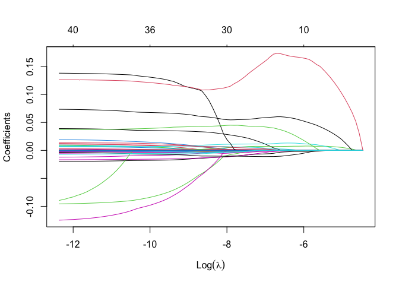

```r
plot(model4,xvar="lambda")
```

```r
model4$beta
```

```
## 41 x 86 sparse Matrix of class "dgCMatrix"
```

```
##   [[ suppressing 86 column names 's0', 's1', 's2' ... ]]
```

```
##
## Abslat      . .          .            .            .           .
## Spanish     . .          .            .            .           .
## French      . .          .            .            .           .
## Brit        . .          .            .            .           .
## WarDummy    . .          .            .            .           .
## LatAmerica  . .          .            .            .           .
## SubSahara   . .          .            .            .           .
## OutwarOr    . .          .            .            .           .
## Area        . .          .            .            .           .
## PrScEnroll  . .          .            .            .           .
## LifeExp     . .          .            .            .           .
## GDP60       . .          .            .            .           .
## Mining      . .          .            .            .           .
## EcoOrg      . .          .            .            .           .
## YrsOpen     . .          0.0008411755 0.0023489833 0.003459478 0.004469387
## Age         . .          .            .            .           .
## Buddha      . .          .            .            .           .
## Catholic    . .          .            .            .           .
## Confucian   . .          .            0.0001621431 0.007347060 0.013893165
## EthnoL      . .          .            .            .           .
## Hindu       . .          .            .            .           .
## Jewish      . .          .            .            .           .
## Muslim      . .          .            .            .           .
## PrExports   . .          .            .            .           .
## Protestants . .          .            .            .           .
## RuleofLaw   . .          .            .            .           .
## Popg        . .          .            .            .           .
## WorkPop     . .          .            .            .           .
## LabForce    . .          .            .            .           .
## HighEnroll  . .          .            .            .           .
## PublEdupct  . .          .            .            .           .
## RevnCoup    . .          .            .            .           .
## PolRights   . .          .            .            .           .
## CivlLib     . .          .            .            .           .
## English     . .          .            .            .           .
## Foreign     . .          .            .            .           .
## RFEXDist    . .          .            .            .           .
## EquipInv    . 0.02989896 0.0520248273 0.0676067272 0.080428670 0.092123524
## NequipInv   . .          .            .            .           .
```

[output cut: 827 more lines]

```
## Popg        -8.811936e-02 -8.958200e-02
## WorkPop     -7.415627e-04 -7.316414e-04
## LabForce     3.188231e-07  3.191047e-07
## HighEnroll  -1.245626e-01 -1.248404e-01
## PublEdupct   1.381172e-01  1.381738e-01
## RevnCoup     3.010491e-03  3.026161e-03
## PolRights    .             .
## CivlLib     -2.201629e-03 -2.204813e-03
## English     -6.846077e-03 -6.863753e-03
## Foreign     -2.136220e-03 -2.155488e-03
## RFEXDist    -1.876806e-05 -1.875207e-05
## EquipInv     1.263518e-01  1.263766e-01
## NequipInv    3.724347e-02  3.722622e-02
## stdBMP      -1.930525e-06 -1.910963e-06
## BlMktPm     -6.650988e-03 -6.666103e-03
```

```r
model4$beta !=0
```

```
## 41 x 86 sparse Matrix of class "lgCMatrix"
```

```
##   [[ suppressing 86 column names 's0', 's1', 's2' ... ]]
```

```
##
## Abslat      . . . . . . . . . . . . . . . . . . . . . . . . . . . . . . . . . .
## Spanish     . . . . . . . . . . . . . . . . . . . . . . . . . . . . . . . . . .
## French      . . . . . . . . . . . . . . . . . . . . . . . . . . . . . . . . . .
## Brit        . . . . . . . . . . . . . . . . . . . . . . . . . . . . . . . . . .
## WarDummy    . . . . . . . . . . . . . . . . . . . . . . . . . . . . . | | | | |
## LatAmerica  . . . . . . . . . . . . . . . . . . . | | | | | | | | | | | | | | |
## SubSahara   . . . . . . . . . . . | | | | | | | | | | | | | | | | | | | | | | |
## OutwarOr    . . . . . . . . . . . . . . . . . . . . . . . . . . | | | | | | | |
## Area        . . . . . . . . . . . . . . . . . . . . . . | | | | | | | | | | | |
## PrScEnroll  . . . . . . . . . . . . . . . . . . . . . . . . . . . . . . . . . .
## LifeExp     . . . . . . . . . . . . . . . . . . . . . . . . . | | | | | | | | |
## GDP60       . . . . . . . . . . . . . . . . . . . . . . . . | | | | | | | | | |
## Mining      . . . . . . . . . . . . . . . . . . . . . . . | | | | | | | | | | |
## EcoOrg      . . . . . . . . . . . . . . . . | | | | | | | | | | | | | | | | | |
## YrsOpen     . . | | | | | | | | | | | | | | | | | | | | | | | | | | | | | | | |
## Age         . . . . . . . . . . . . . . . . . . . . | | | | | | | | | | | | | |
## Buddha      . . . . . . . | | | | | | | | | | | | | | | | | | | | | | | | | | |
## Catholic    . . . . . . . . . . . . . . . . . . . . . . . . . | . . . . . . . .
## Confucian   . . . | | | | | | | | | | | | | | | | | | | | | | | | | | | | | | |
## EthnoL      . . . . . . . . . . . . . . . . . . . . . . . . . . . . . . . . . .
## Hindu       . . . . . . . . . . . . . . . . . . . . . . . . . . . . . . . . | |
## Jewish      . . . . . . . . . . . . . . . . . . . . . . . . . . . . . . . . . .
## Muslim      . . . . . . . . . . . . . . . . . . | | | | | | | | | | | | | | | |
## PrExports   . . . . . . . . . . . . . . . . . . . . . . . . . . | | | | | | | |
## Protestants . . . . . . . . . . . . . | | | | | | | | | | | | | | | | | | | | |
## RuleofLaw   . . . . . . . . . . . . . . . . . . . . . . . . | | | | | | | | | |
## Popg        . . . . . . . . . . . . . . . . . . . . . . . . . . . . . . . . . .
## WorkPop     . . . . . . . . . . . . . . . . . . . . . . . . . . . . . | | | | |
## LabForce    . . . . . . . . . . . . . . . . . . . . . . . . . . . . . . . . . .
## HighEnroll  . . . . . . . . . . . . . . . . . . . . . . . . . . . . . . . . . .
## PublEdupct  . . . . . . . . . . . . . . . . . . . . . . . . . . . . . . . . . .
## RevnCoup    . . . . . . . . . . . . . . . . . . . . . . . . . . . . . . . . . .
## PolRights   . . . . . . . . . . . . . . . . . . . . . . . . . . . . . . . . | |
## CivlLib     . . . . . . . . . . . . . . . . . . . . . . . . . . . . . . . . . .
## English     . . . . . . . . . . . . . . . . . . . . . . . . . . . . | | | | | |
## Foreign     . . . . . . . . . . . . . . . . . . . . . . . . . . . . . . . . . .
## RFEXDist    . . . . . . . . . . . . . . . | | | | | | | | | | | | | | | | | | |
## EquipInv    . | | | | | | | | | | | | | | | | | | | | | | | | | | | | | | | | |
## NequipInv   . . . . . . . . . . . . . | | | | | | | | | | | | | | | | | | | | |
```

[output cut: 71 more lines]

```
## Popg        | | | | | | | | | | | | | | | | | |
## WorkPop     | | | | | | | | | | | | | | | | | |
## LabForce    | | | | | | | | | | | | | | | | | |
## HighEnroll  | | | | | | | | | | | | | | | | | |
## PublEdupct  | | | | | | | | | | | | | | | | | |
## RevnCoup    | | | | | | | | | | | | | | | | | |
## PolRights   | | | | | | | | | . . . . . . . . .
## CivlLib     | | | | | | | | | | | | | | | | | |
## English     | | | | | | | | | | | | | | | | | |
## Foreign     | | | | | | | | | | | | | | | | | |
## RFEXDist    | | | | | | | | | | | | | | | | | |
## EquipInv    | | | | | | | | | | | | | | | | | |
## NequipInv   | | | | | | | | | | | | | | | | | |
## stdBMP      | | | | | | | | | | | | | | | | | |
## BlMktPm     | | | | | | | | | | | | | | | | | |
```

```r
set.seed(1)

cvlassoeg <- cv.glmnet(x,eg1$y)
cvlassoeg$glmnet.fit  ### glmfit on entire data
```

```
##
## Call:  glmnet(x = x, y = eg1$y)
##
##    Df  %Dev    Lambda
## 1   0  0.00 0.0115300
## 2   1  6.87 0.0105100
## 3   2 13.30 0.0095730
## 4   3 19.31 0.0087230
## 5   3 26.69 0.0079480
## 6   3 32.82 0.0072420
## 7   3 37.90 0.0065990
## 8   4 42.67 0.0060120
## 9   4 46.81 0.0054780
## 10  4 50.25 0.0049920
## 11  4 53.10 0.0045480
```

[output cut: 75 more lines]

```r
optlambdaeg<- cvlassoeg$lambda.min
optlambdaeg
```

```
## [1] 3.955711e-05
```

```r
coef(model4, exact=T,s=optlambdaeg)
```

```
## 42 x 1 sparse Matrix of class "dgCMatrix"
##                        s0
## (Intercept)  6.766367e-02
## Abslat       .
## Spanish      8.649734e-03
## French       6.274067e-03
## Brit         4.949970e-03
## WarDummy    -2.013873e-03
## LatAmerica  -9.134184e-03
## SubSahara   -1.788533e-02
## OutwarOr    -3.806519e-03
## Area         .
## PrScEnroll   1.512684e-02
## LifeExp      8.246821e-04
## GDP60       -1.576397e-02
## Mining       3.573062e-02
## EcoOrg       1.183938e-03
## YrsOpen      .
## Age         -2.069281e-05
## Buddha       6.791278e-03
## Catholic     .
## Confucian    6.804853e-02
## EthnoL       1.246551e-02
## Hindu       -8.587785e-02
## Jewish      -1.720637e-03
## Muslim       6.400234e-03
## PrExports   -3.668793e-03
## Protestants -6.698833e-03
## RuleofLaw    9.648727e-03
## Popg         .
## WorkPop     -1.536171e-03
## LabForce     2.851773e-07
## HighEnroll  -1.006389e-01
## PublEdupct   1.320805e-01
## RevnCoup     1.800390e-03
## PolRights   -3.400694e-04
## CivlLib     -1.599233e-03
## English     -5.536048e-03
## Foreign     -7.560549e-04
## RFEXDist    -1.689834e-05
## EquipInv     1.221412e-01
## NequipInv    3.908181e-02
## stdBMP      -2.837298e-06
## BlMktPm     -5.786942e-03
```